# Skills Quiz: Residuals, Sums of Squares, and R-squared

## Instructions

Use this file to keep a record of your work as you complete the “Skills Quiz: Residuals, Sums of Squares, and R-squared” assignment in Canvas.

## Problem 1 {Done}

Open the `Orange` dataset in R. As stated in the help file for this data set, “The Orange data… records of the growth of orange trees.”

Perform a simple linear regression of the circumference of the tree based on its age in days.

```r
# Perform the Test
#View(Orange)
mylm <- lm(circumference ~ age, data = Orange)
summary(mylm)
```

```
##
## Call:
## lm(formula = circumference ~ age, data = Orange)
##
## Residuals:
##     Min      1Q  Median      3Q     Max
## -46.310 -14.946  -0.076  19.697  45.111
##
## Coefficients:
##              Estimate Std. Error t value Pr(>|t|)
## (Intercept) 17.399650   8.622660   2.018   0.0518 .
## age          0.106770   0.008277  12.900 1.93e-14 ***
## ---
## Signif. codes:  0 '***' 0.001 '**' 0.01 '*' 0.05 '.' 0.1 ' ' 1
##
## Residual standard error: 23.74 on 33 degrees of freedom
## Multiple R-squared:  0.8345, Adjusted R-squared:  0.8295
## F-statistic: 166.4 on 1 and 33 DF,  p-value: 1.931e-14
```

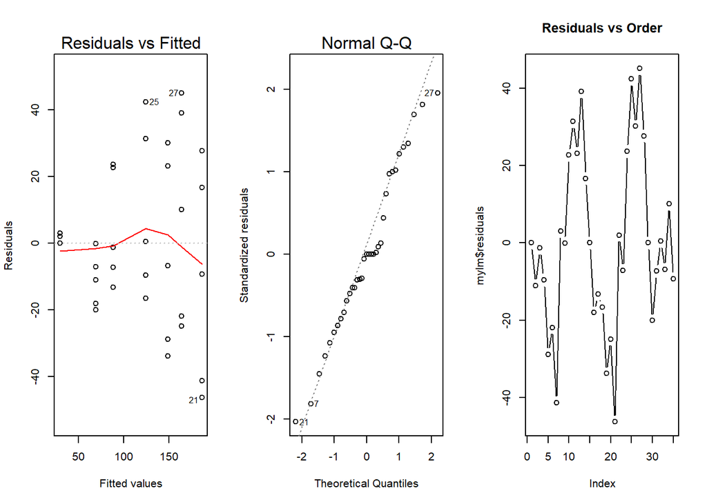

```r
# Check Assumptions
par(mfrow=c(1,3))
plot(mylm, which=1:2)
plot(mylm$residuals, type = "b", main = "Residuals vs Order")
```

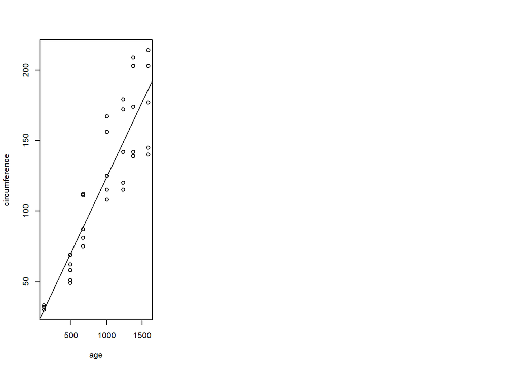

```r
#plot(mylm, which = 1)
# qqPlot(mylm$residuals, main = "Q-Q Plot of Residuals", id = FALSE)

#Plot the Regression Line
plot(circumference ~ age, data = Orange)
abline(mylm)
```

### Part (a) {Done}

Type out the mathematical equation for this regression model and label both $Y$ and $X$ in the equation.

$$\underbrace{Y_i}_\text{Tree's Circumference} = \overbrace{{\underbrace{\beta_0}_\text{Intercept} + \underbrace {\beta_1}_\text{Slope}}\underbrace{X_i}_\text{Age}}^\text{True Regression Line} + \epsilon_i \quad \text{where} \ \epsilon_i \sim N(0, \sigma^2)$$

### Part (b) {Done}

Plot a scatterplot of the data with your regression line overlaid.

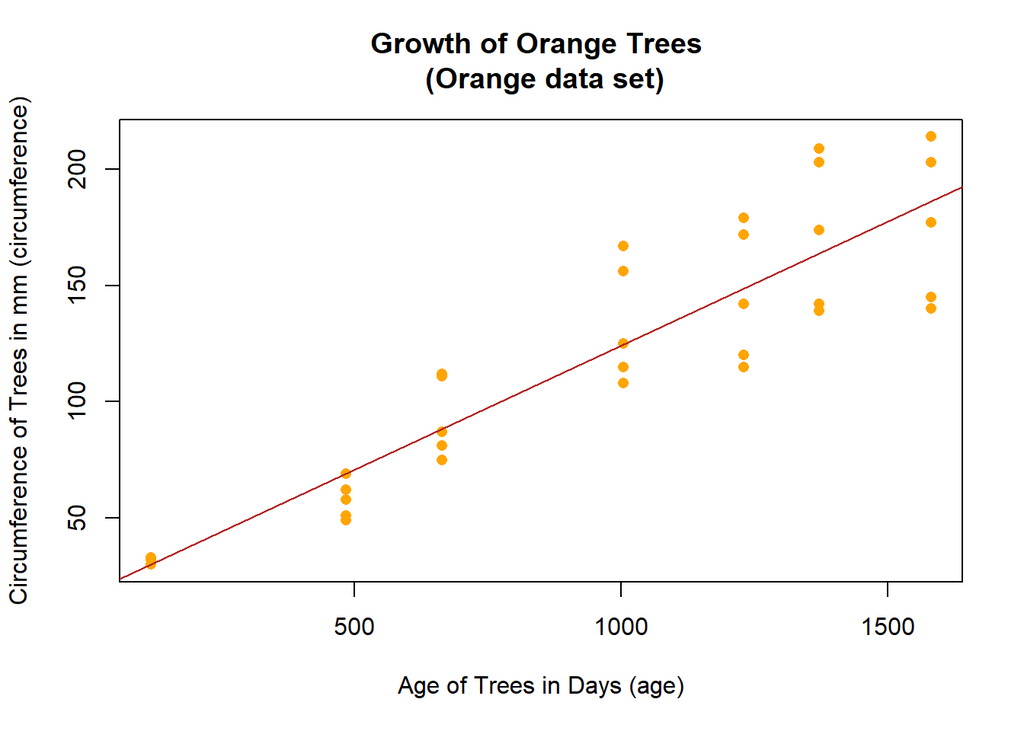

```r
# Plot a scatterplot
plot(circumference ~ age,
     data = Orange,
     col="orange",
     pch=16,
     main = "Growth of Orange Trees \n (Orange data set)",
     ylab= "Circumference of Trees in mm (circumference)",
     xlab= "Age of Trees in Days (age)")
abline(mylm,
       col="firebrick")
```

### Part (c) {Done}

State and interpret the slope and y-intercept of this regression. Are they meaningful for this data?

The slope is $0.106770$ with a $p$-value of **1.93e-14**. This has great significance to use. However, the y-intercept, $17.399650$, has a $p$-value of **0.0518**.

### Part (d) {Done}

What are the values of SSE, SSR, SSTO, $R^2$, and the correlation $r$ for this regression?

```r
# SSE
sum(mylm$res^2)
```

```
## [1] 18594.74
```

```r
# SSR
sum( (mylm$fit - mean(Orange$circumference))^2 )
```

```
## [1] 93771.54
```

```r
SSR <- sum( (mylm$fit - mean(Orange$circumference))^2 )

# SSTO
sum( (Orange$circumference - mean(Orange$circumference))^2 )
```

```
## [1] 112366.3
```

```r
SSTO <- sum( (Orange$circumference - mean(Orange$circumference))^2 )

# R^2
SSR/SSTO
```

```
## [1] 0.8345167
```

```r
# r
cor(Orange$age, Orange$circumference)
```

```
## [1] 0.9135189
```

### Part (e) {Done}

How do the values of SSR and SSTO relate to the correlation?

When I divide SSR by SSTO, I will get $R^2$. If I then square root $R^2$, I will be able to get the value of the correlation.

### Part (f) {Done}

What circumference would we expect orange trees to have on average after 3 years, based on this regression?

```r
17.399650 + 0.106770*(3*365)
```

```
## [1] 134.3128
```

## Problem 2 {Done}

Open the **mtcars** dataset in R. Fit three different regression models to the data that can each be used to explain average gas mileage of a vehicle (`mpg`).

- The first regression should use the weight (`wt`) of the vehicle as the explanatory variable.
- The second should use the number of cylinders (`cyl`) of the engine of the vehicle as the explanatory variable.
- The third should use the gross horsepower of the vehicle (`hp`) as the explanatory variable.

```r
# Perform the Test

wt.lm <- lm(mpg ~ wt, data = mtcars)
summary(wt.lm)
```

```
##
## Call:
## lm(formula = mpg ~ wt, data = mtcars)
##
## Residuals:
##     Min      1Q  Median      3Q     Max
## -4.5432 -2.3647 -0.1252  1.4096  6.8727
##
## Coefficients:
##             Estimate Std. Error t value Pr(>|t|)
## (Intercept)  37.2851     1.8776  19.858  < 2e-16 ***
## wt           -5.3445     0.5591  -9.559 1.29e-10 ***
## ---
## Signif. codes:  0 '***' 0.001 '**' 0.01 '*' 0.05 '.' 0.1 ' ' 1
##
## Residual standard error: 3.046 on 30 degrees of freedom
## Multiple R-squared:  0.7528, Adjusted R-squared:  0.7446
## F-statistic: 91.38 on 1 and 30 DF,  p-value: 1.294e-10
```

```r
cyl.lm <- lm(mpg ~ cyl, data = mtcars)
summary(cyl.lm)
```

```
##
## Call:
## lm(formula = mpg ~ cyl, data = mtcars)
##
## Residuals:
##     Min      1Q  Median      3Q     Max
## -4.9814 -2.1185  0.2217  1.0717  7.5186
##
## Coefficients:
##             Estimate Std. Error t value Pr(>|t|)
## (Intercept)  37.8846     2.0738   18.27  < 2e-16 ***
## cyl          -2.8758     0.3224   -8.92 6.11e-10 ***
## ---
## Signif. codes:  0 '***' 0.001 '**' 0.01 '*' 0.05 '.' 0.1 ' ' 1
##
## Residual standard error: 3.206 on 30 degrees of freedom
## Multiple R-squared:  0.7262, Adjusted R-squared:  0.7171
## F-statistic: 79.56 on 1 and 30 DF,  p-value: 6.113e-10
```

```r
hp.lm <- lm(mpg ~ hp, data = mtcars)
summary(hp.lm)
```

```
##
## Call:
## lm(formula = mpg ~ hp, data = mtcars)
##
## Residuals:
##     Min      1Q  Median      3Q     Max
## -5.7121 -2.1122 -0.8854  1.5819  8.2360
##
## Coefficients:
##             Estimate Std. Error t value Pr(>|t|)
## (Intercept) 30.09886    1.63392  18.421  < 2e-16 ***
## hp          -0.06823    0.01012  -6.742 1.79e-07 ***
## ---
## Signif. codes:  0 '***' 0.001 '**' 0.01 '*' 0.05 '.' 0.1 ' ' 1
##
## Residual standard error: 3.863 on 30 degrees of freedom
## Multiple R-squared:  0.6024, Adjusted R-squared:  0.5892
## F-statistic: 45.46 on 1 and 30 DF,  p-value: 1.788e-07
```

### Part (a) {Done}

Plot all three regressions in three separate plots.

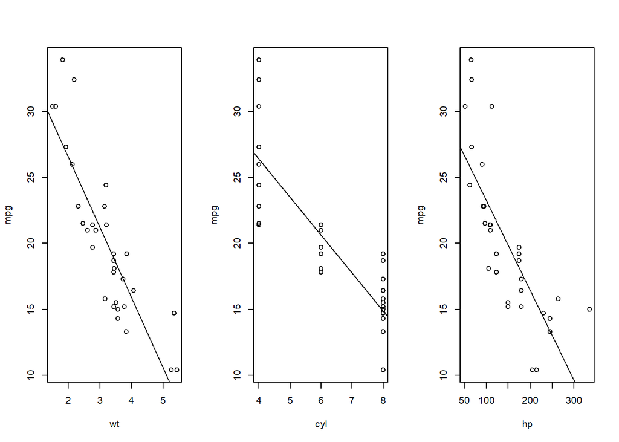

```r
par(mfrow=c(1,3))

plot(mpg ~ wt, data = mtcars)
abline(wt.lm)

plot(mpg ~ cyl, data = mtcars)
abline(cyl.lm)

plot(mpg ~ hp, data = mtcars)
abline(hp.lm)
```

### Part (b) {Done}

State the values of SSE, SSR, SSTO, and $R^2$ for each regression.

```r
# plot(mpg ~ wt, data = mtcars)
# abline(wt.lm)


# SSE
sum( (mtcars$mpg - wt.lm$fit)^2)
```

```
## [1] 278.3219
```

```r
# SSR
sum( (wt.lm$fit - mean(mtcars$mpg))^2 )
```

```
## [1] 847.7252
```

```r
# SSTO
sum( (mtcars$mpg - mean(mtcars$mpg))^2 )
```

```
## [1] 1126.047
```

```r
# R^2
SSR <- sum( (wt.lm$fit - mean(mtcars$mpg))^2 )
SSTO <- sum( (mtcars$mpg - mean(mtcars$mpg))^2 )
SSR/SSTO
```

```
## [1] 0.7528328
```

```r
# r
cor(mtcars$wt, mtcars$mpg)
```

```
## [1] -0.8676594
```

```r
# plot(mpg ~ cyl, data = mtcars)
# abline(cyl.lm)


# SSE
sum( (mtcars$mpg - cyl.lm$fit)^2)
```

```
## [1] 308.3342
```

```r
# SSR
sum( (cyl.lm$fit - mean(mtcars$mpg))^2 )
```

```
## [1] 817.713
```

```r
# SSTO
sum( (mtcars$mpg - mean(mtcars$mpg))^2 )
```

```
## [1] 1126.047
```

```r
# R^2
SSR <- sum( (cyl.lm$fit - mean(mtcars$mpg))^2 )
SSTO <- sum( (mtcars$mpg - mean(mtcars$mpg))^2 )
SSR/SSTO
```

```
## [1] 0.72618
```

```r
# r
cor(mtcars$cyl, mtcars$mpg)
```

```
## [1] -0.852162
```

```r
# plot(mpg ~ hp, data = mtcars)
# abline(hp.lm)

# SSE
sum( (mtcars$mpg - hp.lm$fit)^2)
```

```
## [1] 447.6743
```

```r
# SSR
sum( (hp.lm$fit - mean(mtcars$mpg))^2 )
```

```
## [1] 678.3729
```

```r
# SSTO
sum( (mtcars$mpg - mean(mtcars$mpg))^2 )
```

```
## [1] 1126.047
```

```r
# R^2
SSR <- sum( (hp.lm$fit - mean(mtcars$mpg))^2 )
SSTO <- sum( (mtcars$mpg - mean(mtcars$mpg))^2 )
SSR/SSTO
```

```
## [1] 0.6024373
```

```r
# r
cor(mtcars$hp, mtcars$mpg)
```

```
## [1] -0.7761684
```

### Part (c) {Done}

Compare the values from **Part (b)** across each regression. Consider these questions as you compare these numbers.

- What insight do these numbers give about the regression?
- Which numbers change, which stay the same, in these regressions? Why?
- Which regression is best at explaining average `mpg` according to these numbers?
- What insight do these numbers give about the regression?

  The closer they are to 1 the better my regression line and the data points line up with one another.
- Which numbers change, which stay the same, in these regressions? Why?

  All of the number change except for the SSTO value because it’s the same information for all three. I’m taking the Y variable and subtracting the mean of the Y variable squared from it.
- Which regression is best at explaining average `mpg` according to these numbers?

Before we can really trust the $R^2$ value from a regression model, there are important diagnostic checks to perform on the regression.

You now have a better understanding of what a **residual** and a **fitted-value** are in regression. With that improved knowledge, work through the following problem.

## Problem 3 {Talk with Saunders}

Check the following technical details for each of the three regressions of **Problem 2**.

### Part (a) {Done}

Create a (1) residuals vs. fitted-values plot, (2) Q-Q Plot of the residuals, and (3) residuals vs. order plot for each regression of **Problem 2**.

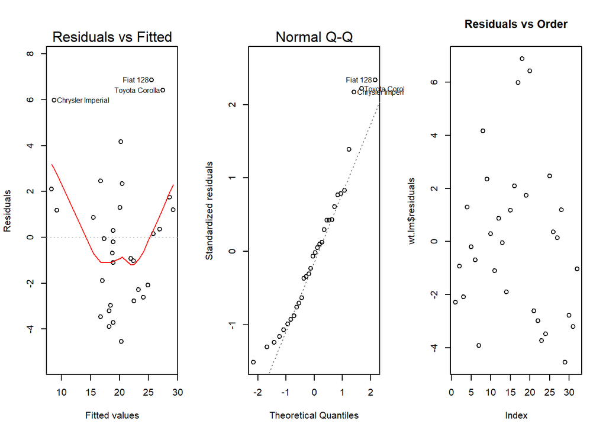

```r
par(mfrow=c(1,3))
plot(wt.lm, which=1:2)
plot(wt.lm$residuals, main = "Residuals vs Order")
```

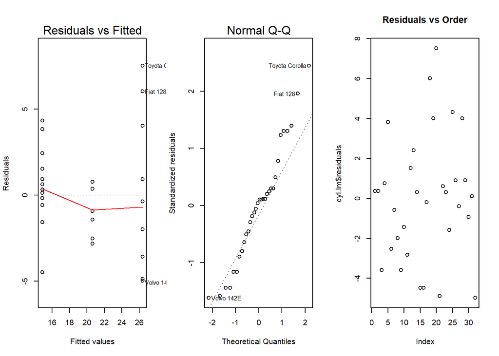

```r
par(mfrow=c(1,3))
plot(cyl.lm, which=1:2)
plot(cyl.lm$residuals, main = "Residuals vs Order")
```

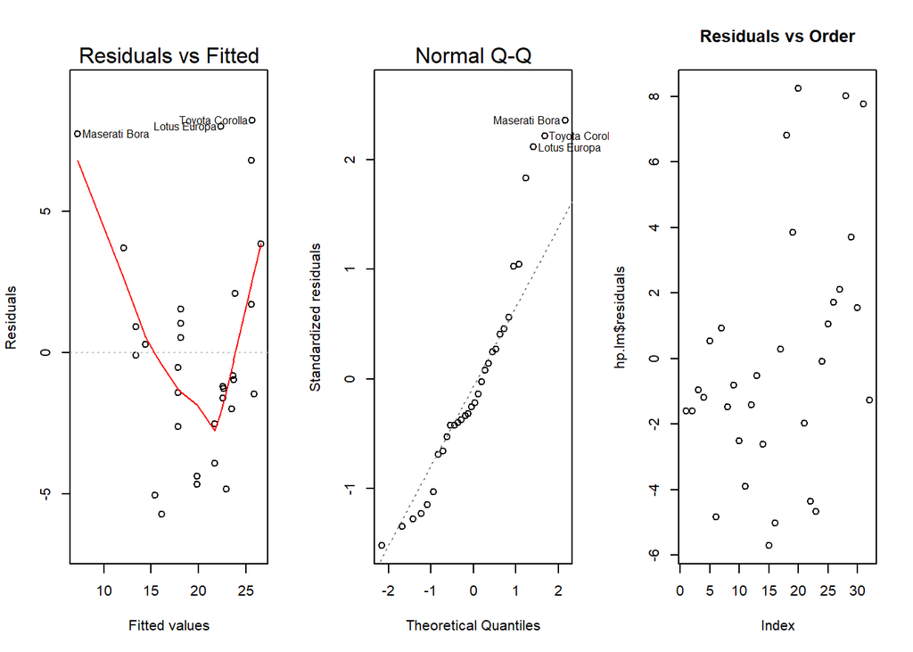

```r
par(mfrow=c(1,3))
plot(hp.lm, which=1:2)
plot(hp.lm$residuals, main = "Residuals vs Order")
```

### Part (b) {Talk with Saunders}

Explain, as best you understand currently, what each of these three plots show for these regressions.

The plots for the Weight Linear Model show that the relation between the Y and X variable are not linear.

The plots for the Cylindar Linear Model look like both the relation between the Y and X variable are not linear *and* that the variance between the error terms are not constant.

### Part (c) {Talk with Saunders}

Comment on whether or not we should trust the $R^2$ value from each of your three regressions based on your plots in Part (a).